# ESTUDIO DEL NIVEL DE RUIDO EN EL BARRIO DE RUZAFA

Grado en Ciencia de Datos-Universidad de Valencia

Gabriel Val Ballester

2022-06-27

# 1 .Introduccion

Este proyecto tiene como objetivo analizar los datos obtenidos por catorce sonómetros situados en distintas calles del barrio de Ruzafa.Trataremos de saber el porqué de ciertos niveles de ruido en ciertas épocas del año a través de visualizaciones que nos favoreceran su comprensión.

Estos datos han sido recogidos por parte del Ayuntamiento de Valencia en su portal de datos abiertos: https://www.valencia.es/dadesobertes/es/data/?groups=medio-ambiente

# 2 .Descarga de datos

Para la descarga de los datos, hemos optado por automatizar la descarga, ya que cada día se añade un nuevo registro. Para ello, hemos obtenido los identificadores y los nombres que queriamos para cada uno de los archivos y con esto hemos podido automatizar el proceso de descarga y guardado de ellos.

De esta parte del estudio obtenemos catorce archivos csv ,donde cada uno de ellos contiene la informacion respectiva a cada uno de los sonómetros situados,colocados en una carpeta llamada data. La correspondencia entre el sonómetro y el nombre de el archivo que contiene su información es

**‘data/Sueca_Esq_Denia.csv’** : Datos diarios del sensor de ruido ubicado en el barrio de Ruzafa, en la calle Sueca Esq. Denia

**‘data/Cadiz_16.csv’** : Datos diarios del sensor de ruido ubicado en el barrio de Ruzafa, en la calle Cádiz, 16

**‘data/Cadiz_3.csv’** : Datos diarios del sensor de ruido ubicado en el barrio de Ruzafa, en la calle Cádiz, 3

**‘data/Cuba_3.csv’** : Datos diarios del sensor de ruido ubicado en el barrio de Ruzafa, en la calle Cuba, 3

**‘data/Sueca_2.csv’** : Datos diarios del sensor de ruido ubicado en el barrio de Ruzafa, en la calle Sueca, 2

**‘data/Sueca_61.csv’** : Datos diarios del sensor de ruido ubicado en el barrio de Ruzafa, en la calle Sueca, 61

**‘data/Sueca_32.csv’** : Datos diarios del sensor de ruido ubicado en el barrio de Ruzafa, en la calle Sueca, 32

**‘data/Carles_Cervera_Chaflan_Reina_Donya_Maria.csv’** : Datos diarios del sensor de ruido ubicado en el barrio de Ruzafa, en la calle Carles Cervera, Chaflán Reina Doña María

**‘data/Salvador_Abril_Chaflan_Maestro_Jose_Serrano.csv’** : Datos diarios del sensor de ruido ubicado en el barrio de Ruzafa, en la calle Salvador Abril Chaflán Maestro José Serrano

**‘data/Vivons_Chaflan_Cadiz.csv’** : Datos diarios del sensor de ruido ubicado en el barrio de Ruzafa, en la calle Vivons Chaflán Cádiz

**‘data/Carles_Cervera_34.csv’** : Datos diarios del sensor de ruido ubicado en el barrio de Ruzafa, en la calle Carles Cervera, 34

**‘data/Puerto_Rico_21.csv’** : Datos diarios del sensor de ruido ubicado en el barrio de Ruzafa, en la calle Puerto Rico, 21

**‘data/Doctor_Serrano_21.csv’** : Datos diarios del sensor de ruido ubicado en el barrio de Ruzafa, en la calle Doctor Serrano, 21

**‘data/General_Prim_Chaflan_Donoso_Cortes.csv’** : Datos diarios del sensor de ruido ubicado en el barrio de Ruzafa, en la calle General Prim Chaflán Donoso Cortés

# 3 Carga de datos

La carga de datos se hará de forma automatizada,cogiendo cada uno de los archivos,corvintiendolos a informacion de estructura dataframe y asignandolos a cada uno de los nombres que queremos que tengan.

Hemos creado una columna extra para cada datframe llamada **Place**

## 3.1 Unificación de los datos

Para poder trabajar comodamente y de una manera eficiente con los datos vamos a unificarlos todos en un solo dataframe

Hay que tener ciertas cosas en cuenta para que la unificación sea posibles

Primero me creo una lista de los dataframes para poder trabajar bien con ella

Luego habra que comprobar si comparten el numero de columnas para ver si podemos apilar registros

Una vez hemos comprobado que todos ellos tienen de dimension de columna **12**,ahora hay que ver si las variables evaluan lo mismo.Para ello veremos si coinciden en nombre y tipo.

Una vez comprobado que los dataframes tienen el mismo número y nombre de columnas,es decir **12** y _id, recvTime, fiwareServicePath, entityType, entityId, LAeq, LAeq_d, LAeq_den, LAeq_e, LAeq_n, dateObserved, Place podemos juntarlos y trabajar con ellos.

El siguiente paso es unificarlos en un solo dataframe que tendrá este aspecto

| _id | recvTime | fiwareServicePath | entityType | entityId | LAeq | LAeq_d | LAeq_den | LAeq_e | LAeq_n | dateObserved | Place |
| --- | --- | --- | --- | --- | --- | --- | --- | --- | --- | --- | --- |
| 1 | 2020-09-18 12:40:17 | /sonometros | NoiseLevelObserved | T248671-daily | 60.9 | 62.3 | 63.9 | 61.0 | 55.4 | 2020-09-17 | Cadiz 16 |
| 2 | 2020-09-19 00:00:27 | /sonometros | NoiseLevelObserved | T248671-daily | 61.7 | 63.2 | 64.5 | 62.2 | 55.4 | 2020-09-18 | Cadiz 16 |
| 3 | 2020-09-20 00:00:31 | /sonometros | NoiseLevelObserved | T248671-daily | 60.2 | 60.8 | 64.7 | 63.2 | 57.1 | 2020-09-19 | Cadiz 16 |
| 4 | 2020-09-21 00:00:33 | /sonometros | NoiseLevelObserved | T248671-daily | 57.9 | 58.1 | 63.6 | 59.3 | 57.1 | 2020-09-20 | Cadiz 16 |
| 5 | 2020-09-22 00:00:36 | /sonometros | NoiseLevelObserved | T248671-daily | 61.2 | 63.1 | 63.1 | 59.6 | 52.5 | 2020-09-21 | Cadiz 16 |
| 6 | 2020-09-23 00:00:39 | /sonometros | NoiseLevelObserved | T248671-daily | 61.0 | 62.8 | 63.0 | 59.9 | 52.6 | 2020-09-22 | Cadiz 16 |

## 3.2 Variables de nuestro dataframe

Antes de empezar a analizar los datos en profuncdidad vamos a conocer lo que tenemos,es decir que información nos dan nuestras variables.

| Parametros | Significado |
| --- | --- |
| _id | Identificador para cada registro |
| recvTime | Fecha en la que se insertó el dato en la plataforma |
| fiwareServicePart | Servicio de la plataforma VLCi al que pertenece el sensor |
| entityType | Tipo de entidad del sensor en la plataforma VLCi |
| entityId | Identificador único del sensor en la plataforma VLCi |
| LAeq | Nivel sonoro continuo equivalente. El período establecido para este sensor es de 1 minuto. Es una media ponderada según la frecuencia que varía constantemente |
| LAeq_d | Es un indicador de ruido asociado al día, donde al día le corresponden 12 horas, en el período que se extiende desde las 7 hasta las 19 horas |
| LAeq_den | índice de ruido día-tarde-noche, es utilizado para determinar la molestia vinculada a la exposición al ruido |
| LAeq_e | Es un indicador del nivel sonoro durante la tarde, donde a la tarde le corresponden 4 horas, en el período que se extiende desde las 19 hasta las 23 horas |
| LAeq_n | Es un indicador del nivel sonoro durante la noche, donde a la noche le corresponden 8 horas, en el período que se extiende desde las 23 hasta las 7 horas |
| DateObserved | Día al que se refieren las medidas. |
| Place | Lugar donde ocurrieron cada uno de los registros |

# 4 Limpiado del dataframe

En esta parte del estudio nos vamos a encargar de obtener un tidy dataset,es decir un dataframe mas representativo y claro. Para eso vamos a llevar a cabo distintos pasos para completarlo.

## 4.1 Seleccion de columnas adecuadas

Primero hay que ver con que columnas nos quedamos y cuales no nos dan información valiosa y por lo tanto no nos quedamos con ellas.

De primeras se puede observar como en las columnas entityType y fiwareServicePath los datos guardados en cada una de ellas son los mismos.Si esto se cumple no nos interesaran como información ya que no añaden nada.

Como nuestra suposición se cumple ya sabemos que estas dos columnas no aportan ninguna información.A parte,ni _id ni recvTime me aportan informacion ya que me es suficiente con la variable dateObserved en caso de recvTime e _id pierde su caracter identificador.

| entityId | LAeq | LAeq_d | LAeq_den | LAeq_e | LAeq_n | dateObserved | Place |
| --- | --- | --- | --- | --- | --- | --- | --- |
| T248671-daily | 60.9 | 62.3 | 63.9 | 61.0 | 55.4 | 2020-09-17 | Cadiz 16 |
| T248671-daily | 61.7 | 63.2 | 64.5 | 62.2 | 55.4 | 2020-09-18 | Cadiz 16 |

## 4.2 Renombramiento de las variables

Para la facilitación de las posteriores operaciones renombramos las columnas.

| entityId | ruido_min | ruido_dia | ruido_max | ruido_tarde | ruido_noche | dateObserved | Place |
| --- | --- | --- | --- | --- | --- | --- | --- |
| T248671-daily | 60.9 | 62.3 | 63.9 | 61.0 | 55.4 | 2020-09-17 | Cadiz 16 |
| T248671-daily | 61.7 | 63.2 | 64.5 | 62.2 | 55.4 | 2020-09-18 | Cadiz 16 |

## 4.3 Cambio de tipo variables

Hay ciertas a las que no les corresponde su tipo de dato

## 4.4 Conjunto Tidy

Hay que juntar las columnas de las variables que miden el ruido y luego separarlas en dos ,una con el tipo y otra con los valores

| entityId | dateObserved | Place | tipo | Valores |
| --- | --- | --- | --- | --- |
| T248671-daily | 2020-09-17 | Cadiz 16 | min | 60.9 |
| T248671-daily | 2020-09-17 | Cadiz 16 | dia | 62.3 |
| T248671-daily | 2020-09-17 | Cadiz 16 | max | 63.9 |
| T248671-daily | 2020-09-17 | Cadiz 16 | tarde | 61.0 |
| T248671-daily | 2020-09-17 | Cadiz 16 | noche | 55.4 |
| T248671-daily | 2020-09-18 | Cadiz 16 | min | 61.7 |

# 5 Deteccion de outliers

En esta parte vamos a buscar datos que no esten en un rango marcado por ellos mismos(los conocidos como outliers).Estos valores son conocidos como infinitos,perdidos o inusuales y provacan cambios en el comportamiento del analisis a traves de estadisticos de ellos y por tanto afectan al modelo.

```
   Min. 1st Qu.  Median    Mean 3rd Qu.    Max.
   21.0    57.6    60.7     Inf    63.3     Inf
```

Aun asi nos damos cuenta de que existen registros cuyo valor es infinito

Procedemos de la siguiente forma

En primer lugar determinamos la posicion de los datos cuyo valor es infinito

| x |
| --- |
| 989 |
| 22592 |

Como son solo dos el numero de infinitos podemos o bien obviar estos registros o imputarlos a la media.

Nos quedamos con un dataframe de **37188**

Luego comprobamos si existen valores `NA`

No existen datos `NA` y por lo tanto estos eran los unicos registros que contenian datos erroneos.

| entityId | dateObserved | Place | tipo | Valores |
| --- | --- | --- | --- | --- |

## 5.1 Analisis univariante y Estaditicos

Lo primero que haremos de todo será definirnos una serie de estadisticos basicos sobre los que trabajaremos en variables numericas

| estadisticos | Significado |
| --- | --- |
| min | Calcula del minimo de los datos |
| max | Calcula del maximo de los datos |
| mean | Calculo de la media de los datos |
| median | Calculo de la mediana de los datos |
| var | Medida de dispersion de datos |
| sd | Medida de dispersion de datos |
| IQR | Medida de dispersion de datos |

Aplicamos los estadisticos sobre nuestra variable numerica,Valores.Si hubiese algun valor perdido `NA` hay que eliminar

| Stat | Valor |
| --- | --- |
| min | 21.000000 |
| max | 97.400000 |
| mean | 60.511496 |
| median | 60.700000 |
| var | 31.639627 |
| sd | 5.624911 |
| IQR | 5.700000 |

Este diagrama nos muestra como de eficaz pueden llegar a ser los estadisticos para el analisis de los datos

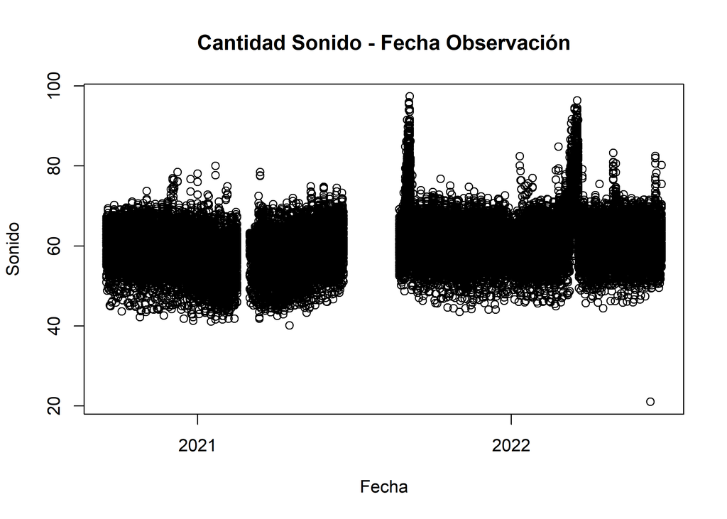

Los valores que obtenemos en el estudio estadistico coinciden con los mostrados en el diagrama Los valores medios y medianas se acercan a lo representado,el valor minimo se ve que se acerca a 21…

Al final los estadisticos buscan darnos un hilo al que seguir a la hora de analizar un conjunto de datos,pero no podemos basarlo todo en ellos yaque no son lo suficentemente concretos

Los siguiente será ver si las variables siguen un tipo de distribución gaussiana o no.

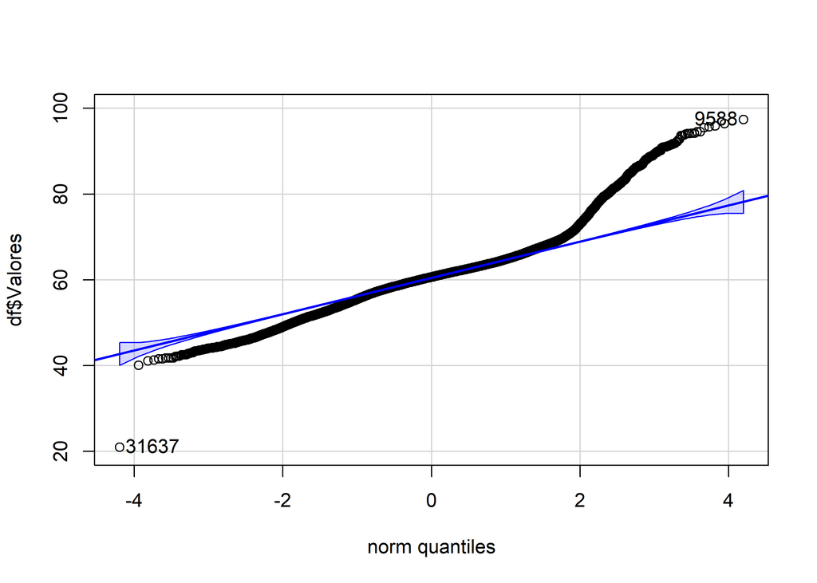

```
[1] 31637  9588
```

Como podemos ver es que nuestro conjunto de datos no sigue una distribucion gaussiana.Esto habrá que tenerlo en cuenta para el posterior analisis

Para ver la distribcuion de los valores del sonido vamos a representar un histograma.

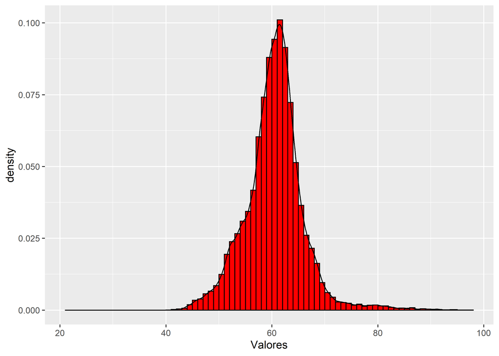

Podemos ver que aunque parezca que sigue una distribucion gaussiana,es irregular en partes.

## 5.2 Analisis Bivariante

Analisis bivariante como se le conoce el analisis de la relacion entre dos variables(correlacion/covarianza).

Una forma de ver la asociacion numerica entre dos variables es la covarianza.Esta forma nos indica donde tiende a estar una variable cuando la otra esta por debajo o encima de su media.

Primero vemos graficamente como la relacion entre dos variables para una misma medicion en calle,en este caso para Cuba_3.Este analisis grafico no sera tan eficiente como la aplicacion del coeficiente de correlacion pero si nos servira de guia

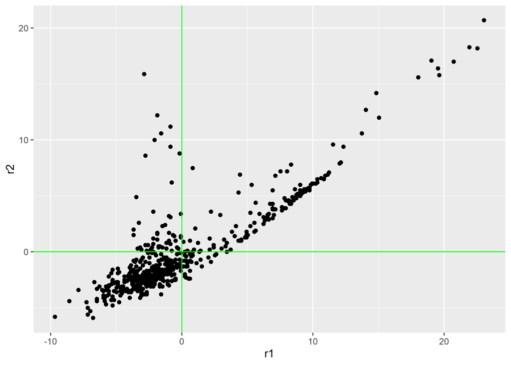

Estas dos primeras variables **LAeq_n** y **LAeq_den** concentran una gran cantidad de puntos cerca por lo que parece que la relacion entre ellas es alta

Vista la relacion grafica,para poder afinar mas en nuestro estudio vamos a aplicar el coeficiente de correlacion,la relacion lineal entre las dos variables.

`1`.Los datos estan entre -1 y 1

`2`.Si se acercan a uno el grado de relacion es alta

`3`.Si se acercan a -1 el grado de relacion es minima

| 1.00 | 0.86 |
| --- | --- |
| 0.86 | 1.00 |

Como los valores son proximos a uno, podemos decir que el grado de relacion lineal entre ellos es alto.

Ahora volvemos a aplicar estos mismos procedimientos sobre las variables **LAeq_e** y **dateObserved** Procedimiento grafico

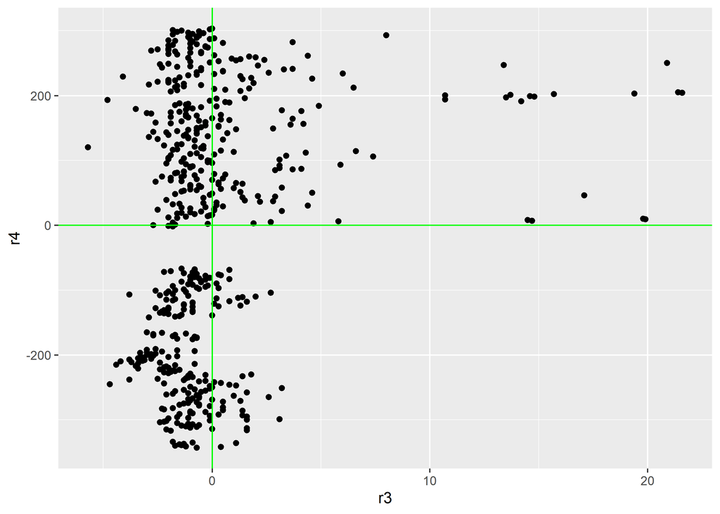

A simple vista se ven los datos mas dispersos que en grafico anterior

Procediemiento numerico

| 1.00 | 0.22 |
| --- | --- |
| 0.22 | 1.00 |

Como los valores no son tan cercanos a uno,podemos decir que el grado de relacion lineal entre ellos es mas bajo que el de las dos primeras variables.

# 6 Preguntas

Tras toda esta preparacion de los datos nos vamos a plantear una serie de preguntas:

## 6.1 ¿Cual es el mes donde mas ruido se produce?

Para estudiar cada uno de los cinco tipos de ruido que hay tengo que definirlos Correspondiendo cada uno de ellos con:

-**min**: Nivel sonoro continuo equivalente. En este caso el período establecido para este sensor es de 1 minuto.

-**dia**: Es un indicador de ruido asociado al día.

-**tarde**: Es un indicador del nivel sonoro durante la tarde.

-**noche**: Es un indicador del nivel sonoro durante la noche.

-**max**: índice de ruido día-tarde-noche, es utilizado para determinar la molestia vinculada a la exposición al ruido.

Me creo un grafico donde muestro con graficos boxplot cuales son los niveles de db que mas se producen a lo largo de cada mes del año para los cinco tipos de sonidos que hay

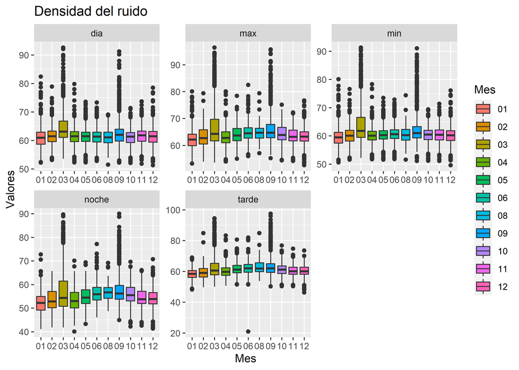

## 6.2 ¿Que estación del año es en la que menos se contamina?

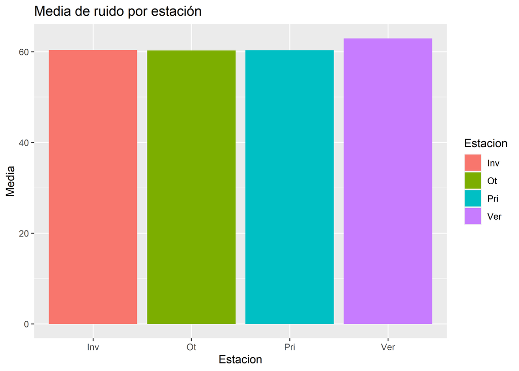

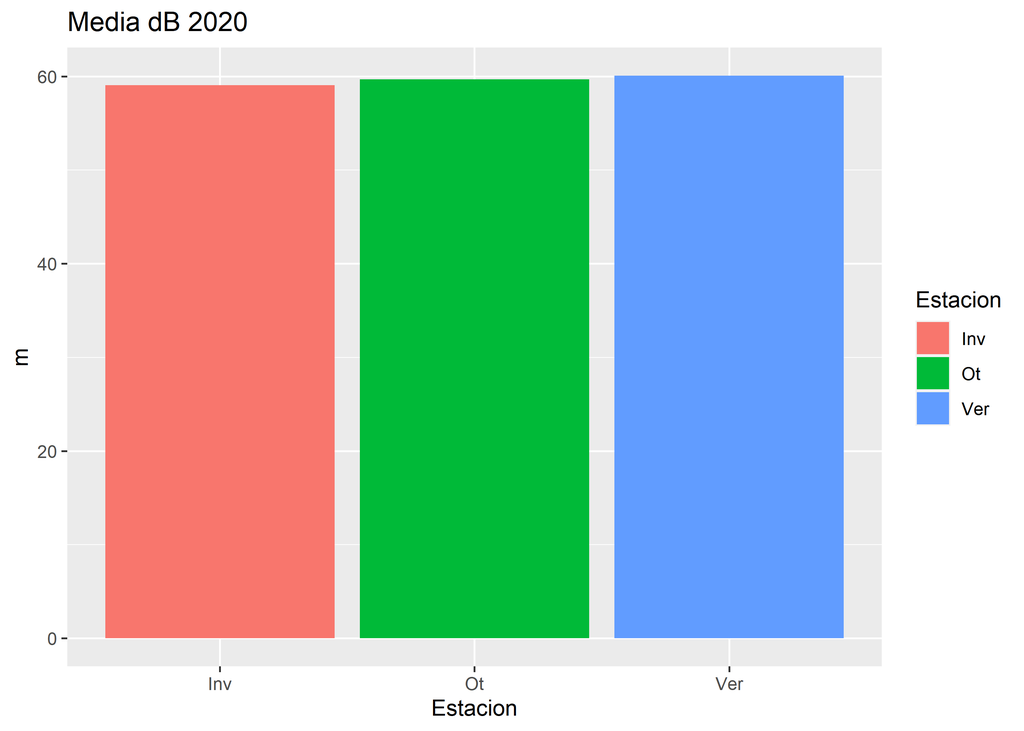

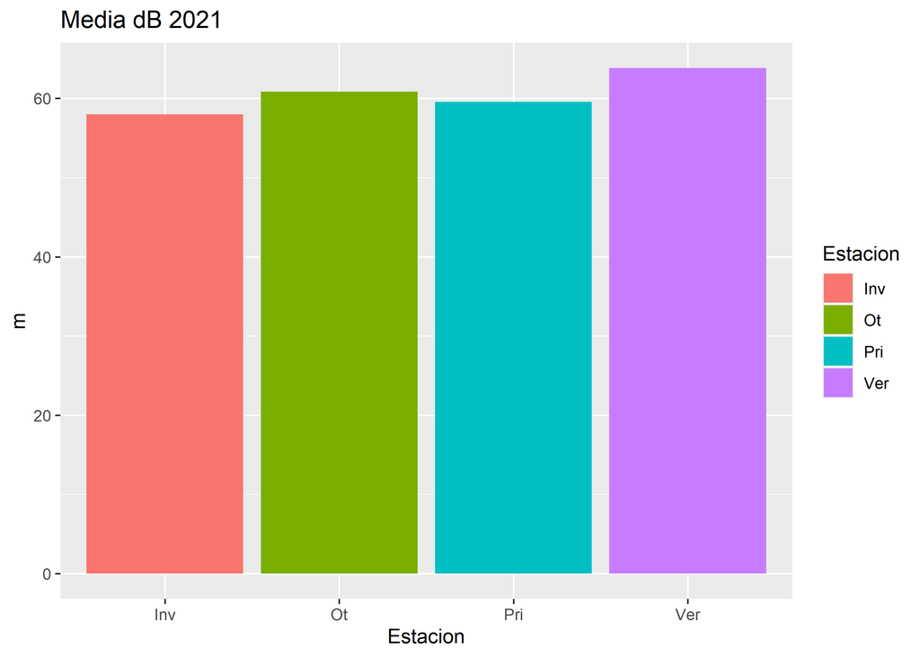

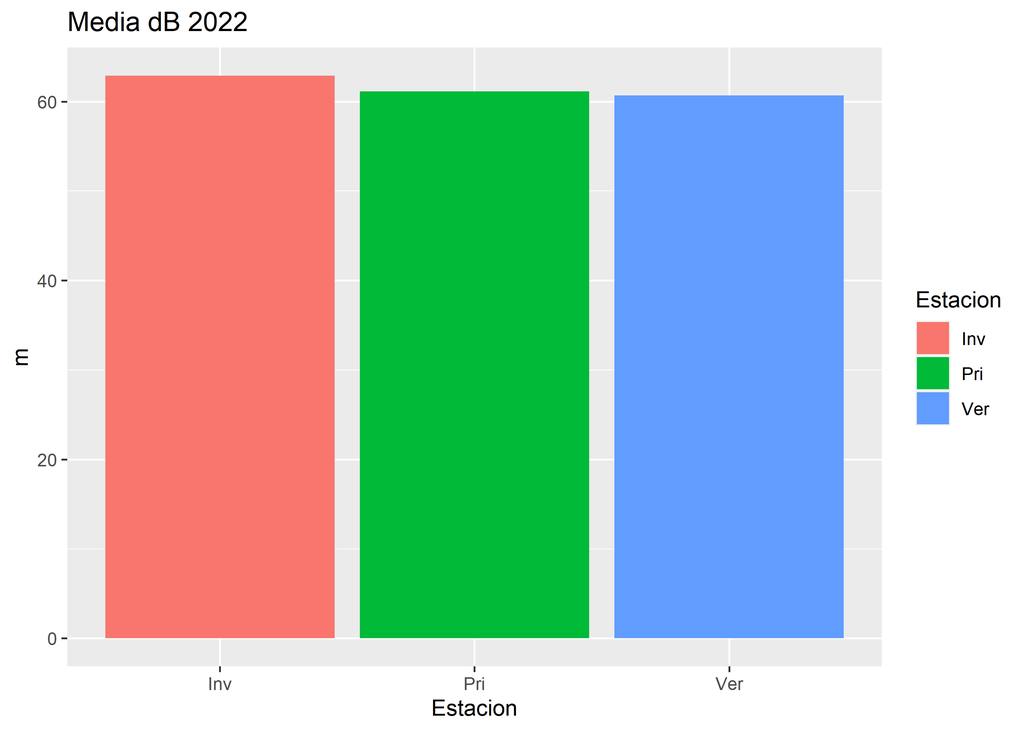

Como podemos ver, en líneas generales todas la estaciones suelen tener una media de ruido parecida estando el verano un escalón por encima. Algo también a destacar es la disparidad que encontramos en el año 2021 donde el ruido captado en verano es mayor que en el resto de estaciones esto es debido a que en 2021 las fallas se celebraron a principios de septiembre

## 6.3 ¿En que año hubo mas ruido?

El año con mas ruido se refiere al año donde mas ruido hubo de una manera continuada ,sin tener en cuenta los altos y bajos de sonido que puede haber a lo largo de un año

Esto se hace con la media.

Usamos el dataframe amd que es el que tiene las columnas Anyo,Mes y Dia

Lo haremos de forma grafica y numerica

Forma numerica

```
# A tibble: 3 x 2
  Anyo  Valores
  <fct>   <dbl>
1 2020     59.6
2 2021     60.0
3 2022     61.9
```

Forma grafica

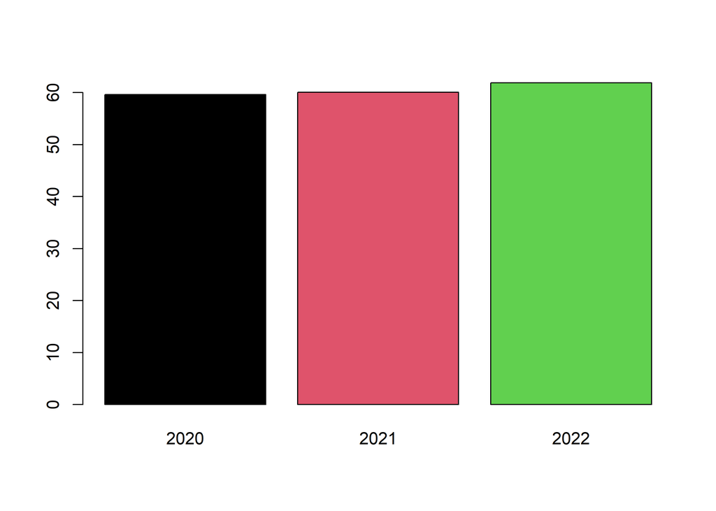

Como podemos ver el año donde hubo mas ruido fue el 2022

Para concluir, haremos un repaso general de las conclusiones que hemos extraído de los distintos gráficos y tablas.

*La celebracion de las Fallas en Valencia incrementa considerablemente el nivel de ruido.

*Los niveles de ruido son superiores o cercanos a los 55 db,que es el limite maximo permisible para las zonas residenciales

*El año 2022 fue en el que mas ruido hubo.Se debe en gran parte a la extincion de la pandemia